# LIMS_data

Marlin

2023-06-15

## Data placeholder

This vignette covers the high frequency data collected by the Wisconsin State Lab of Hygiene. This Wastewater data covers 6 weeks of 9 measurements a day of 6 day a week. This has 17 columns where 4 categorical variables and 13 measurement columns which analyse 6 signals.

```r
library(DSIWastewater)
library(dplyr)
library(ggplot2)

data(HFGWaste_data, package = "DSIWastewater")
```

The data is broken down by site, date, Filter and well. Site is where is was collected from a range of 10 locations. Filter and Well are what level of replicates it is. Filter is the High level category representing the different collections. Well contains the info about what technique batch it was. The numbering of the category are arbitrary from day to day.

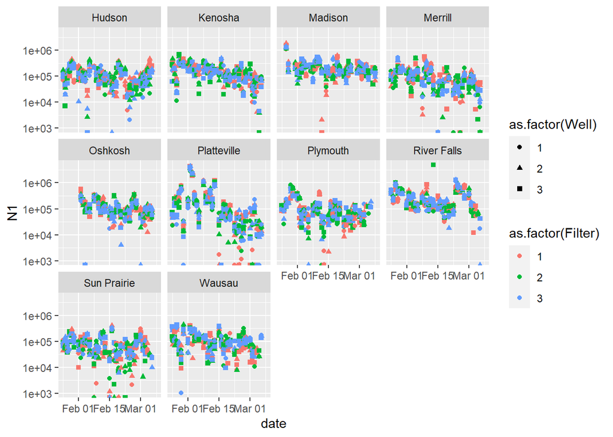

```r
HFGWaste_data%>%
  ggplot(aes(x = date, y = N1, color = as.factor(Filter), shape = as.factor(Well)), size = .5)+
  geom_point()+
  scale_y_log10()+
  facet_wrap(~site)
```

Otherwise the signals measured were N1 and N2, different genes of Covid-19, PMMOV, BCoV, HF183, and CrP, which are suppose to functions as normalizes. These signals can have a couple of different companion columns. The Ct version is what the machine measured which was the number of spins to detect the genes. This is an exponential decay transformation to the Base column. The other extra column is the LOD which says if the measurement was bellow the Labs level of detection. This might mean the exact number is less reliable.

```r
head(HFGWaste_data)
```

```
##     site       date Filter Well  N1Ct     N1 N1LOD  N2CT     N2 N2LOD PMMOVCT
## 1 Hudson 2021-01-25      1    1 33.25  70268 FALSE 33.70  40121  TRUE   24.96
## 2 Hudson 2021-01-25      1    2 31.86 171547 FALSE 32.87  67953 FALSE   24.89
## 3 Hudson 2021-01-25      1    3 32.88  88856 FALSE 33.21  54756  TRUE   25.15
## 4 Hudson 2021-01-25      2    1 32.20 138137 FALSE 32.11 110372 FALSE   25.21
## 5 Hudson 2021-01-25      2    2 31.89 168132 FALSE 32.16 107241 FALSE   25.22
## 6 Hudson 2021-01-25      2    3 32.72  98634 FALSE 32.88  67862 FALSE   25.18
##     PMMOV BCoV HF183CT     HF183 CrPCT       CrP Notes
## 1 8335368 1.92   28.05 236887243 29.66 119023953  <NA>
## 2 8756036 2.06   28.22 210693707 29.92  99677418  <NA>
## 3 7268880 1.95   28.60 162485283 30.06  90503607  <NA>
## 4 6945237 4.15   27.88 265156508 29.94  98203103  <NA>
## 5 6917604 4.76   28.27 203828374 30.05  91220128  <NA>
## 6 7103485 6.10   27.71 296482397 29.95  97912594  <NA>
```

We used this data set in some analysis [here](https://github.com/AFIDSI/Covid19-Wastewater-Analysis/tree/main/results/CoVariants)